# Read mapping and visualisation

11-10-2022

# Intro

In the previous tutorial (Genome assembly and validation), we removed spurious contigs (small and/or with a low K-mer coverage).

In this second assembly validation tutorial, we will map the reads back to the assemblies to get an idea of how well the reads support the assemblies. The mapping will be done on the cluster, and you will generate the coverage plots on your own computer using *R*.

You will need:

- Your assembly file (with the small contigs removed)
  - In the previous tutorial we had copied it out of the assembly directory, filtered and named it `03_<ESL0xxx>_contigs_filtered.fasta`
- The quality-filtered reads that were used for the assembly.
  - They were called `01_<ESL0xxx>_R1_paired.fastq.gz` and `01_<ESL0xxx>_R2_paired.fastq.gz`.
- The corresponding concatenated version (containing a single header and the concatenated contigs sequences)
  - We will concatenate them in the first part of the tutorial.

By now, you are expected to know how to copy files between your computer and the cluster, and to find and to load software. These commands are therefore not provided in this tutorial. If you have forgotten how to do these things, go back to the previous tutorials.

# Part 1 : Mapping reads against the assembly

## Preparation

Prepare your working directory for this session -

1. Log-in to the cluster
2. Navigate to your working directory in the sage main directory)
3. Create a new directory called `03_ReadsMapping` for the analysis. Within this directory you need to copy:
   - The filtered reads (`01_<ESL0xxx>_R1_paired.fastq.gz` and `01_<ESL0xxx>_R2_paired.fastq.gz`)
   - The filtered assembly file (`03_<ESL0xxx>_contigs_filtered.fasta`)
4. Follow the tutorial to create a concatenated version of the assembly (a single header and the concatenated contigs sequences)

### Creating the concatenated file

In order to make the read mapping and plotting easier, you will start by concatenating the contigs into a single sequence. This can be accomplished in several ways (R, python, ..). Here is a quick version using bash commands.

First, generate a new file containing a single fasta header (for example, the contig header name will be *concat_<ESL0xxx>* and the new file *concat_<ESL0xxx>.fasta*).

```bash
# ! Adapt the header name and the file name to your own file !
echo ">concat_<ESL0xxx>" > concat_<ESL0xxx>.fasta
```

Take a look inside the file with `less`. What do you see ? Do you understand the command line you executed ?

Now, add the contig sequences to the file, but exclude the headers !

```bash
# ! Adapt the names to your own file !
cat 03_<ESL0xxx>_contigs_filtered.fasta | grep -v '>' >> concat_<ESL0xxx>.fasta
```

- What does the `-v` option do ?
- What is the difference between the single `'>'` and the double `'>>'` arrows ?
- Check your file with less
- How can you make sure you only have one header ?

## Mapping the reads

For this section we will run a series of commands in a batch script that we will call `run_bwa.sh`. The steps that you will execute in this script are described below.

Use the same Slurm options that you used in `run_spades.sh`. Remember to rename the error and output files

### Exercise 1.1: Loading the software

Find and load the software. We will need `samtools` and `bwa`. Check the software versions and use `module load` to load the modules and `spider` to check any dependencies

#### DIY

```bash
...
module spider <software>
module load <software>
...
...
module avail
```

Expected result: bwa and samtools should be available “in your path”. In plain english, if you type “samtools” or “bwa” in the terminal, you should get some instructions for how to uses the programs. If you use module avail to check, you should see (L) next to the module(s) you need

#### Hints

```bash
######Loading samtools ######
module spider samtools
# ------------------------------------------
#   samtools: samtools/1.12
# ------------------------------------------
#
#     You will need to load all module(s) on any one of the lines below before the "samtools/1.12" module is available to load.
#
#       gcc/9.3.0
#
#     Help:
#       SAM Tools provide various utilities for manipulating alignments in the
#       SAM format, including sorting, merging, indexing and generating
#       alignments in a per-position format

# check with module avail if gcc and intel modules are already loaded. Else :
module load gcc
module load samtools

###### Loading bwa ######
# module spider bwa/0.7.17
# ------------------------------------------
#   bwa: bwa/0.7.17
# ------------------------------------------
#
#     You will need to load all module(s) on any one of the lines below before the "bwa/0.7.17" module is available to load.
#
#       gcc/9.3.0
#
#     Help:
#       Burrow-Wheeler Aligner for pairwise alignment between DNA sequences.
module load bwa/0.7.17
# To check if the modules are correctly loaded
module avail
```

> Do now Create your script `run_bwa.sh` (inside your new 03_ReadsMapping directory) and add the appropriate lines into your script to load bwa and samtools. Have a look at your previous scripts if you do not remember how to do this

### Indexing the concatenated assembly fasta-file

Before mapping the reads, the concatenated assembly fasta-file needs to be indexed. An index is a data structure technique which allows to quickly access data and records from a file.

```bash
bwa index concat_<ESL0xxx>.fasta
```

> Do now Add the bwa index command from the above code chunk to your script

### Mapping the reads to the assembly

The mem command “aligns 70bp-1Mbp query sequences with the BWA-MEM algorithm. Briefly, the algorithm works by seeding alignments with maximal exact matches (MEMs) and then extending seeds with the affine-gap Smith-Waterman algorithm (SW).” *source:* http://bio-bwa.sourceforge.net/bwa.shtml

```bash
bwa mem concat_<ESL0xxx>.fasta 01_<ESL0xxx>_R1_paired.fastq.gz 01_<ESL0xxx>_R2_paired.fastq.gz > <ESL0xxx>.sam
```

> Do now Add the `bwa mem` command to your script

### Convert the sam file to a bam file

```bash
samtools view -b <ESL0xxx>.sam > <ESL0xxx>.bam
```

> Do now Add the `samtools view` command to your script

### Sort the bam file

Now, you need to sort the reads according to their mapping position

```bash
samtools sort <ESL0xxx>.bam > <ESL0xxx>_sorted.bam
```

> Do now Add the `samtools sort` command to your script

### Coverage per base

In order to (later) plot the base coverage, you need to generate a text-file with the coverage per base information.

```bash
samtools depth -a <ESL0xxx>_sorted.bam > <ESL0xxx>_depth.txt
```

> Do now Add the `samtools depth` command to your script

### Exercise 1.2: Read mapping

#### Questions

- Run the script. What the outputs produced? Do you understand them all?

#### Hints

Below is a brief description of the output expected from each command in your script.

This is how your script should look

```bash
#!/bin/bash

######### SLURM OPTIONS
#SBATCH --account jgianott_sage
#SBATCH --job-name read_mapping
#SBATCH --nodes 1
#SBATCH --ntasks 1
#SBATCH --cpus-per-task 8
#SBATCH --mem 6G
#SBATCH --time 1:00:00
#SBATCH --export NONE
#SBATCH --error /scratch/jgianott/SAGE/SAGE2022_2023/<username>/logs/read_mapping.err
#SBATCH --output /scratch/jgianott/SAGE/SAGE2022_2023/<username>/logs/read_mapping.out

######### COMMANDS TO LOAD MODULES

module load gcc
module load bwa
module load samtools

##### VARIABLES
username=<username>
genome_id=<ESL0xxx>

##### Execute commands

#move to the directory 03_ReadMapping
cd /scratch/jgianott/SAGE/SAGE2022_2023/${username}/03_ReadsMapping

#execute the indexing, mapping, conversion to BAM, sorting BAM and depth:
bwa index concat_${genome_id}.fasta
bwa mem concat_${genome_id}.fasta 01_${genome_id}_R1_paired.fastq.gz 01_${genome_id}_R2_paired.fastq.gz > ${genome_id}.sam
samtools view -b ${genome_id}.sam > ${genome_id}.bam
samtools sort ${genome_id}.bam > ${genome_id}_sorted.bam
samtools depth -a ${genome_id}_sorted.bam > ${genome_id}_depth.txt
```

Description of the output expected from each command

- `bwa mem concat_<ESL0xxx>.fasta 01_<ESL0xxx>_R1_paired.fastq.gz 01_<ESL0xxx>_R2_paired.fastq.gz > <ESL0xxx>.sam`

  Expected result: A sam-file, with mapping information for each read (whether it mapped or not, where and how).
  - Have a look inside the file:

  ```bash
  *1* K00382:78:HGVN7BBXY:7:1101:8004:1297    # Sequence ID
  *2* 99      # FLAG = sequence quality expressed as bitwise flag
  *3* CG1.ordered.fasta       # Rname = contig where the read mapped
  *4* 1595631   # POS = Starting position
  *5* 60      # MAPQ = Mapping quality
  *6* 141M    # CIGAR = Describe the position of matches, insertions, deletions with respect to the reference ;  M    alignment match ; I insertion ; D   deletion
  *7* =        # RNEXT = Ref. name of mate read
  *8* 1595690  # PNEXT = Position of mate read

  *9* 210    # TLEN = Observed template length
  *10* AAGCTAAAGTTGCGGGCCACGACATAGACCCCAACTGTCCCACAAGTAATTGCAATAAACGTGCTGGCCAAAAAGGCGTTGCGCATAAATGGTAATGCAAACATTATTCGTACGCCTCCTCAAACTGGGACATCTTGCCCT   # SEQ = Sequence
  *11* AAFFA<FJFJ<F<-A7AJFJJJJFFJFFJJJJJJJJJFJFJJJJFJFFFJ<AJJJ7FFJJJAFF-AFFJFJJJJ-A<FAJFJJJJJJJJFJJJJJA7FJJJJF-AFFJF77FJ7JF7AAJJJFAFFF7-7AF-AAA-AFFA   # QUAL = Base qualities
  ```

- `samtools view -b <ESL0xxx>.sam > <ESL0xxx>.bam` Expected result: A bam-file, which is a binary version of the sam-file, and therefore considerably smaller.
  - What happens if you try to look at the file ?

  ```bash
  p[<FA>8Ҡ#<BA>C<B0>H{e<D5><D4>^B*;<9B>)^^<CD>^ATKsӾi<98>f<A4><F5>!<A7><CD><L<FD>^H<88>@<A4><82>        <C6>^R.d^A<93><D1>.<89><B4><A0>:<94>Z^]<8F>n
  ```

- `samtools sort <ESL0xxx>.bam > <ESL0xxx>_sorted.bam`

  Expected result: A second bam-file. Try `samtools view <ESL0xxx>.bam | less` and `samtools view <ESL0xxx>_sorted.bam | less` to look inside the bam file.
  - Can you see how it has changed ?
- `samtools depth -a <ESL0xxx>_sorted.bam > <ESL0xxx>_depth.txt`

  Expected result: A tab-delimited text-file with three columns. Take a look !
  - What is the -a flag used for ?

# Part 2 : Plotting read coverage in R

> Do now first:
1. Copy your *<ESL0xxx>_depth.txt* file from curnagl to your local computer with the `scp` command.
2. Open a new R script and save it as *readcoverage.R* in the same folder as where you saved *<ESL0xxx>_depth.txt*. It is recommended to make a specific folder for this on your computer where you store all the files for this tutorial.
3. Set your working directory to the folder where you saved both the script and the text file.

Save all code you make in this tutorial in this script and run it from there.

## Read the data into R and check format

There are multiple functions to read text files into R with different default parameters, `read.table()` is a simple one for this instance:

```r
my_cov <- read.table("<ESL0xxx>_depth.txt")
# this works too of course, but we avoided the need by setting the working directory
my_cov <- read.table("full/path/to/<ESL0xxx>_depth.txt")
```

Always first check the object you have read into R. It’s better not to run the entire object (i.e. to run `my_cov`), since it has many rows. Instead use e.g.:

```r
head(my_cov, n = 3) # first 3 lines
```

|  | V1 | V2 | V3 |
| --- | --- | --- | --- |
| 1 | concat_ESL0961 | 1 | 15 |
| 2 | concat_ESL0961 | 2 | 15 |
| 3 | concat_ESL0961 | 3 | 19 |

```r
str(my_cov)         # structure
```

```
## 'data.frame':    3074847 obs. of  3 variables:
##  $ V1: chr  "concat_ESL0961" "concat_ESL0961" "concat_ESL0961" "concat_ESL0961" ...
##  $ V2: int  1 2 3 4 5 6 7 8 9 10 ...
##  $ V3: int  15 15 19 22 22 22 22 24 31 31 ...
```

```r
dim(my_cov)         # dimensions (rows, columns)
```

```
## [1] 3074847       3
```

```r
summary(my_cov)     # summary statistics per column
```

```
##       V1                  V2                V3
##  Length:3074847     Min.   :      1   Min.   :   3.0
##  Class :character   1st Qu.: 768713   1st Qu.:  99.0
##  Mode  :character   Median :1537424   Median : 115.0
##                     Mean   :1537424   Mean   : 128.9
##                     3rd Qu.:2306136   3rd Qu.: 135.0
##                     Max.   :3074847   Max.   :4828.0
```

This tells us we have 3074847 base pairs (rows) on each of which we have 3 variables (columns) with information. The first variable is simply the name of the file you used as input to compute read depth (character class). In other cases, it can for instance contain the contig names. The second variable represents the locus (base pair) and just counts from one to the maximum number of base pairs: 3074847. Since it only has whole numbers (no decimals), it is of class integer. That is also true for the third variable, which is what we are primarily interested in right now: the read depth, or coverage.

It is good practice to give variables an interpretable name, instead of the current `V1`, `V2` and `V3`:

```r
colnames(my_cov)
```

```
## [1] "V1" "V2" "V3"
```

```r
colnames(my_cov) <- c("Genome", "Locus", "Depth")
head(my_cov)
```

|  | Genome | Locus | Depth |
| --- | --- | --- | --- |
| 1 | concat_ESL0961 | 1 | 15 |
| 2 | concat_ESL0961 | 2 | 15 |
| 3 | concat_ESL0961 | 3 | 19 |
| 4 | concat_ESL0961 | 4 | 22 |
| 5 | concat_ESL0961 | 5 | 22 |
| 6 | concat_ESL0961 | 6 | 22 |

### Exercise 2.1: check data

**Remember to write your code in your new R script *readcoverage.R*. Save it every now and then and run your code from there.**

#### Questions

1. Read your *<ESL0xxx>_depth.txt* file into R as an object called `my_cov`, like above.
2. Check if R read the file correctly and give the variables short, easy-to-interpret names.
3. How many points would you be plotting if you would now plot the coverage (`Depth`) per base (`Locus`)? (Do not make this plot.)

#### Answers

```r
# 3.
nrow(my_cov)
#or
length(my_cov$Locus)
```

## Calculating average read coverage per window

We could plot all loci as a function of their depth. However, that’s a lot of data to plot (3074847 points for this example) and that might make R, or your computer, crash. Alternatively, we can simplify by computing the average coverage in windows. Again, there are many ways to do this so you are encouraged to find your own method, but we will show one below.

Say we want to calculate the average coverage per bin of 100 base pairs. However, it is very unlikely that the number of bp of your genome is *exactly* divisible by 100. You could try to find the closest divisor to 100 by which you *can* divide your bp. Here we use a different work-around though, using some standard R functions: some bins will have 100 bp while we allow others to have 99. Here is how many bins we need for that:

```r
nrow(my_cov) / 100          # total nr of bp not exactly divisible by 100
```

```
## [1] 30748.47
```

```r
ceiling(nrow(my_cov) / 100) # instead, divide in so many approximately equal parts
```

```
## [1] 30749
```

We store the number of desired bins in an object called `n_bins` and use it to cut the data with the `cut()` function. This will create the index numbers we need:

```r
n_bins <- ceiling(nrow(my_cov) / 100)
bin_assign <- cut(my_cov$Locus, breaks = n_bins, labels = FALSE)
head(bin_assign, n = 210)
```

```
##   [1] 1 1 1 1 1 1 1 1 1 1 1 1 1 1 1 1 1 1 1 1 1 1 1 1 1 1 1 1 1 1 1 1 1 1 1 1 1
##  [38] 1 1 1 1 1 1 1 1 1 1 1 1 1 1 1 1 1 1 1 1 1 1 1 1 1 1 1 1 1 1 1 1 1 1 1 1 1
##  [75] 1 1 1 1 1 1 1 1 1 1 1 1 1 1 1 1 1 1 1 1 1 1 1 1 1 1 2 2 2 2 2 2 2 2 2 2 2
## [112] 2 2 2 2 2 2 2 2 2 2 2 2 2 2 2 2 2 2 2 2 2 2 2 2 2 2 2 2 2 2 2 2 2 2 2 2 2
## [149] 2 2 2 2 2 2 2 2 2 2 2 2 2 2 2 2 2 2 2 2 2 2 2 2 2 2 2 2 2 2 2 2 2 2 2 2 2
## [186] 2 2 2 2 2 2 2 2 2 2 2 2 2 2 2 3 3 3 3 3 3 3 3 3 3
```

For clarity of what is happening here, we can add the indices to the data frame:

```r
my_cov$bin <- bin_assign
head(my_cov, n = 3); tail(my_cov, n = 3)
```

|  | Genome | Locus | Depth | bin |
| --- | --- | --- | --- | --- |
| 1 | concat_ESL0961 | 1 | 15 | 1 |
| 2 | concat_ESL0961 | 2 | 15 | 1 |
| 3 | concat_ESL0961 | 3 | 19 | 1 |

|  | Genome | Locus | Depth | bin |
| --- | --- | --- | --- | --- |
| 3074845 | concat_ESL0961 | 3074845 | 34 | 30749 |
| 3074846 | concat_ESL0961 | 3074846 | 33 | 30749 |
| 3074847 | concat_ESL0961 | 3074847 | 33 | 30749 |

So we simply assign each base pair to an index number, grouping bp together in bins of about 100.

We can see how many data points will be assigned to each bin using these indices:

```r
head(table(bin_assign)) # table() tabulates the nr of occurrences of each instance
```

```
## bin_assign
##   1   2   3   4   5   6
## 100 100 100 100 100 100
```

Or we can see how many bins will have 99 and how many will have 100 data points:

```r
table(table(bin_assign)) # so here we tabulate the number of times we counted 99 or 100
```

```
##
##    99   100
##    53 30696
```

Do you understand the code and its output?

Now we want to compute the mean read depth per bin. To this end, we can use the `tapply()` function, which applies a given function `FUN` to a given object `X` for each given `INDEX`:

```r
# compute mean depth per bin
Depth_bin <- tapply(X = my_cov$Depth, INDEX = my_cov$bin, FUN = mean)
# compute corresponding mean locus per bin
Locus_bin <- tapply(X = my_cov$Locus, INDEX = my_cov$bin, FUN = mean)
# put together in data frame
my_cov_bin <- data.frame("Locus" = Locus_bin,
                         "Depth" = Depth_bin)
# check made data frame
head(my_cov_bin)
```

|  | Locus | Depth |
| --- | --- | --- |
| 1 | 50.5 | 178.71 |
| 2 | 150.5 | 565.39 |
| 3 | 250.5 | 1000.94 |
| 4 | 350.5 | 1131.70 |
| 5 | 450.5 | 1162.46 |
| 6 | 550.5 | 1173.00 |

Lastly, we want to plot the loci in kbp, or kb, instead of in bp, so that we do not have that many zeroes on our x-axis labels (i.e. for plot readability). So, we make an extra variable in the data frame like this:

```r
my_cov_bin$LocusKB <- my_cov_bin$Locus / 1000
head(my_cov_bin)
```

|  | Locus | Depth | LocusKB |
| --- | --- | --- | --- |
| 1 | 50.5 | 178.71 | 0.0505 |
| 2 | 150.5 | 565.39 | 0.1505 |
| 3 | 250.5 | 1000.94 | 0.2505 |
| 4 | 350.5 | 1131.70 | 0.3505 |
| 5 | 450.5 | 1162.46 | 0.4505 |
| 6 | 550.5 | 1173.00 | 0.5505 |

Now we have a data frame with per 100bp-bin the average read depth and the locus around which we computed it. Ready for plotting!

### Exercise 2.2: Preparing data to plot

**Remember to write your code in your new R script *readcoverage.R*. Save it every now and then and run your code from there.**

1. Compute mean coverage per 100 bp bin from your `my_cov` object and turn it into a data frame called `my_cov_bin`, as above.
2. Add a variable with the loci in kb, instead of bp.
3. Check if your data frame is correct using functions as `head()`, `tail()` and `summary()`.

## Plot read coverage per window

We can plot using the functions available in R base…

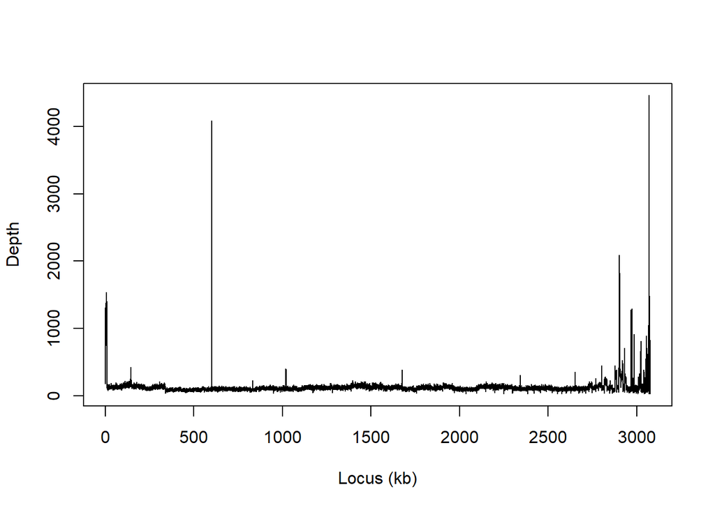

```r
plot(Depth ~ LocusKB,
     data = my_cov_bin,
     type = 'l',
     xlab = "Locus (kb)")
```

…or with ggplot, as before.

```r
# first load the package, install if necessary
#install.packages("ggplot2")
library(ggplot2)
```

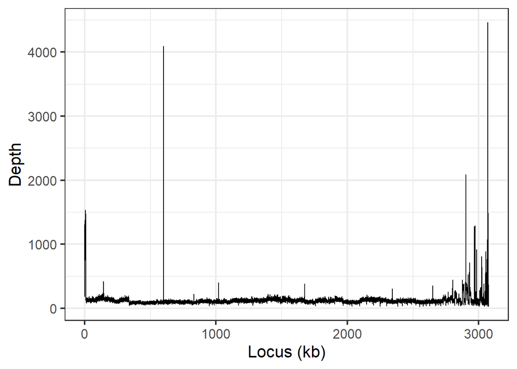

```r
ggplot(my_cov_bin, aes(x = LocusKB, y = Depth)) +
  geom_line() +
  labs(x = "Locus (kb)") +
  theme_bw(base_size = 16)
```

### Exercise 2.3: Plotting read coverage

**Remember to write your code in your new R script *readcoverage.R*. Save it every now and then and run your code from there.**

1. Plot the read coverage as in the example above for your own data using `my_cov_bin`. You can use either R base or ggplot, as you prefer.